# Project 2

## E-new Express

An online news portal aims to expand its business by acquiring new subscribers. Every visitor to the website takes certain actions based on their interest. The company plans to analyze these interests and wants to determine whether a new feature will be effective or not. Companies often analyze users' responses to two variants of a product to decide which of the two variants is more effective. This experimental technique is known as a/b testing that is used to determine whether a new feature attracts users based on a chosen metric.

Suppose you are hired as a Data Scientist in E-news Express. The design team of the company has created a new landing page. You have been assigned the task to decide whether the new landing page is more effective to gather new subscribers. Suppose you randomly selected 100 users and divided them equally into two groups. The old landing page is served to the first group (control group) and the new landing page is served to the second group (treatment group). Various data about the customers in both groups are collected in 'abtest.csv'. Perform the statistical analysis to answer the following questions using the collected data.

Data Dictionary:

- user_id - This represents the user ID of the person visiting the website.
- group - This represents whether the user belongs to the first group (control) or the second group (treatment).
- landing_page - This represents whether the landing page is new or old.
- time_spent_on_the_page - This represents the time (in minutes) spent by the user on the landing page.
- converted - This represents whether the user gets converted to a subscriber of the news portal or not.
- language_preferred - This represents the language chosen by the user to view the landing page.

NB: The level of significance for all statistical tests was 5%.

```python
#importing the required python packages
import pandas as pd  # library used for data manipulation and analysis
import numpy as np  # library used for working with arrays
import matplotlib.pyplot as plt  # library for plots and visualizations
import seaborn as sns  # library for visualizations

%matplotlib inline

import scipy.stats as stats  # this library contains a large number of probability distributions as well as a growing library of statistical functions
```

```python
#Importing the a/b testing dataset
test = pd.read_csv("abtest.csv")
```

```python
#Exploring and Understanding the dataset
print (test.columns) # Lists the names of the columns
print(test.shape) # Prints the number of rows and columns in the
test.head() # Displays the first 5 elements of the data set
```

```
Index(['user_id', 'group', 'landing_page', 'time_spent_on_the_page',
       'converted', 'language_preferred'],
      dtype='object')
(100, 6)
```

|  | user_id | group | landing_page | time_spent_on_the_page | converted | language_preferred |
| --- | --- | --- | --- | --- | --- | --- |
| 0 | 546592 | control | old | 3.48 | no | Spanish |
| 1 | 546468 | treatment | new | 7.13 | yes | English |
| 2 | 546462 | treatment | new | 4.40 | no | Spanish |
| 3 | 546567 | control | old | 3.02 | no | French |
| 4 | 546459 | treatment | new | 4.75 | yes | Spanish |

The data set contains 6 columns and 100 user instances.

```python
# Gather basic info on the data set
test.info()
```

```
<class 'pandas.core.frame.DataFrame'>
RangeIndex: 100 entries, 0 to 99
Data columns (total 6 columns):
 #   Column                  Non-Null Count  Dtype
---  ------                  --------------  -----
 0   user_id                 100 non-null    int64
 1   group                   100 non-null    object
 2   landing_page            100 non-null    object
 3   time_spent_on_the_page  100 non-null    float64
 4   converted               100 non-null    object
 5   language_preferred      100 non-null    object
dtypes: float64(1), int64(1), object(4)
memory usage: 4.8+ KB
```

```python
test.describe() # Gather summary staistics on numerical data
```

|  | user_id | time_spent_on_the_page |
| --- | --- | --- |
| count | 100.000000 | 100.000000 |
| mean | 546517.000000 | 5.377800 |
| std | 52.295779 | 2.378166 |
| min | 546443.000000 | 0.190000 |
| 25% | 546467.750000 | 3.880000 |
| 50% | 546492.500000 | 5.415000 |
| 75% | 546567.250000 | 7.022500 |
| max | 546592.000000 | 10.710000 |

#### Exploratory Data Analysis

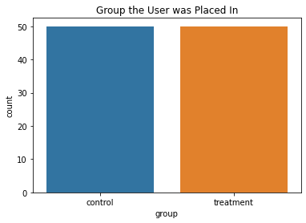

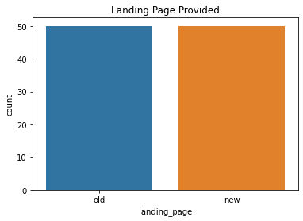

```python
# Looking at the distrbution of the persons in the test among the different test groups
sns.countplot(x=test['group']);
plt.title("Group the User was Placed In")
plt.show()
sns.countplot(x=test['landing_page']);
plt.title("Landing Page Provided")
plt.show()
```

The testing was done with an equal number of persons in the control group and therefore using the old landing page and persons in the treated group, using the new landing page

```
5.377800000000002
```

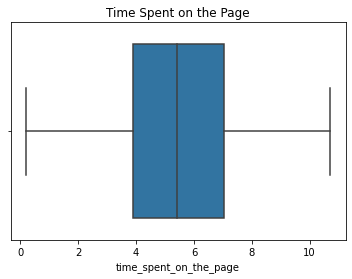

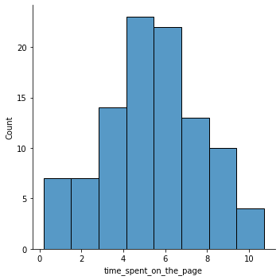

```python
#Looking at how the time spent is distributed
sns.boxplot(x='time_spent_on_the_page',data=test);
plt.title('Time Spent on the Page')
sns.displot(x='time_spent_on_the_page',data=test);
print(test['time_spent_on_the_page'].mean())
```

Users spent between 0 and 10 minutes on the page, on average spending around 5.38 minutes. Most persons spend close to 5 minutes.

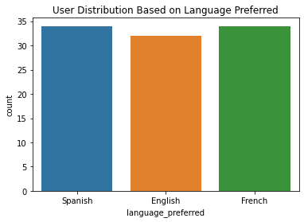

```python
# Distribution of the preferred language
sns.countplot(x=test['language_preferred']);
plt.title('User Distribution Based on Language Preferred')
plt.show()
```

The distribution of preffered language across the sample users was roughly even.

```
yes    54
no     46
Name: converted, dtype: int64
```

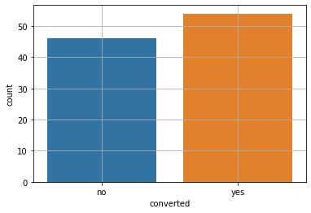

```python
# Identifying the number of persons that was converted in the test group
sns.countplot(x = 'converted',data=test);
plt.grid()
print(test['converted'].value_counts())# Prints the number of persons that converted or did not
```

More than half of the users in the experiment converted. (54 converted while 46 did not convert)

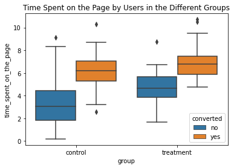

```python
sns.boxplot(y='time_spent_on_the_page',x='group',hue='converted',data = test)
plt.title('Time Spent on the Page by Users in the Different Groups')
plt.show()
```

In both the control and treatment groups, users that eventually became subscribers also spent more time on the page.

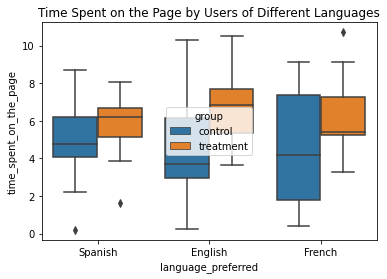

```python
sns.boxplot(y='time_spent_on_the_page',x='language_preferred',hue='group',data = test)
plt.title('Time Spent on the Page by Users of Different Languages')
plt.show()
```

In the control group, on average users , regardless of the preferred language, spent less time on the old landing page (control group) than on the new landing page (treatment group).

## Do users spend more time on the new landing page or the old one?

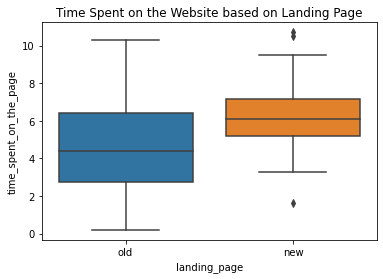

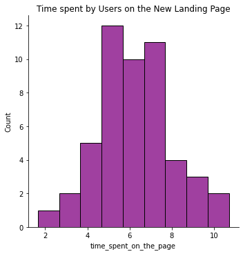

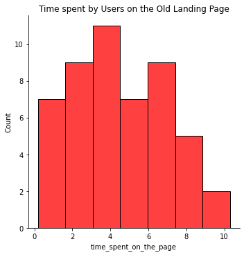

```
landing_page
new    6.22
old    4.53
Name: time_spent_on_the_page, dtype: float64
```

```python
#Visual Analysis of the amount of time spent on each landing page
# Comparing the time spent on the page in the different groups/ different web pages
sns.boxplot(x = 'landing_page', y='time_spent_on_the_page',data=test);
plt.title("Time Spent on the Website based on Landing Page")
plt.show()

#Distribution of the time spent on the new landing page
sns.displot(x='time_spent_on_the_page',data=test[test['landing_page']=='new'].dropna(), color='purple')
plt.title("Time spent by Users on the New Landing Page")
plt.show()

#Distribution of the time spent on the old landign page
sns.displot(x='time_spent_on_the_page',data=test[test['landing_page']=='old'].dropna(),color='r')
plt.title("Time spent by Users on the Old Landing Page")
plt.show()

#Calculates the average time spent on each landing page
print(round(test.groupby(by='landing_page')['time_spent_on_the_page'].mean(),2));
```

Excluding outliers, it seems that users spend more time on the new landing page (on average 6.22 minutes) and less time on the old landing page (average of 4.53 minutes).

```python
#Separating the data into those that used the new landing page versus those that used the old landing page
test_new = test[test['landing_page']=='new'].dropna()
test_old = test[test['landing_page']=='old'].dropna()

#Calcualting the mean time and the standard deviation of the time used on each landing page
print('The mean time spent on the old landing page  is: ', round(test_old['time_spent_on_the_page'].mean(),2))
print('The mean time spent on the new landing page  is: ', round(test_new['time_spent_on_the_page'].mean(),2))
print('The standard deviation of the time spent on the old landing page  is: ', round(test_old['time_spent_on_the_page'].std(),2))
print('The standard deviation of the time spent on the new landing page  is: ', round(test_new['time_spent_on_the_page'].std(),2))
```

```
The mean time spent on the old landing page  is:  4.53
The mean time spent on the new landing page  is:  6.22
The standard deviation of the time spent on the old landing page  is:  2.58
The standard deviation of the time spent on the new landing page  is:  1.82
```

The data is impling that more time is spent on the new landing page than the old. In order to verify this we will conduct a statistical test.

### Statistical Analysis - 2 Sample T Test for Population Mean

###### Step 1: Define null and alternate hypotheses

$H_0$ : The average time spent on each landing page is the same

$H_a$ : Users spend more time on the new landing page

###### Step 2: Indentifying the Appropriate Test

We are comparing the mean from two samples. Assumptions:

- Continuous Data - The time is measured on a continuous scale
- Normally distributed population or sample sizes >30 - Since both sample sizes are greater than 30 the central limit theorem states that the distribution os the sample means will be normal
- Independent Populations - We are taking the samples for two different pages from independent populations
- Unequal population standard deviations - The population sample deviations are unknown, but the sample standard deviations differ significantly therefore we assume that the population standard deviations will also differ
- Random sampling - We are told that the sampleing is random

A 2 sample t test with unequal variances will be most appropriate for this problem.

.

##### Step 3: Decide the Level of Significance

As given in the problem statement, we select α = 0.05.

##### Step 4: Calulate the p -value

```python
# Import the function for a 2 sample t test
from scipy.stats import ttest_ind

#calcualting the p-value
test_stat1, pval1 = ttest_ind(test_new['time_spent_on_the_page'],test_old['time_spent_on_the_page'],equal_var=False, alternative='greater')
print('The p-value for this test is: ', round(pval1,5))
```

```
The p-value for this test is:  0.00014
```

#### Compare the p-value with α

Since the p vaue 0.014% is significantly less than α = 5%, we reject the null hypothesis and thus the data suggests that users spend more time on the new landing page.

## Is the conversion rate (the proportion of users who visit the landing page and get converted) for the new page greater than the coversion rate for the old page?

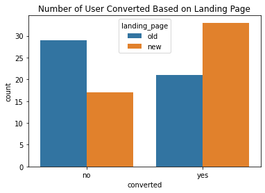

```
landing_page  converted
new           yes          33
              no           17
old           no           29
              yes          21
Name: converted, dtype: int64
```

```python
#Exploring the relationship between the conversion rate and the landing page
sns.countplot(x='converted',hue='landing_page',data=test);
plt.title("Number of User Converted Based on Landing Page")
plt.show()
# Calculate the number of persons that converted based on the landing page
print(test.groupby(by='landing_page')['converted'].value_counts())
```

More persons, 33, were converted when using the new landing page rather than the old landing page, 21.

```python
# Calculating the conversion rates for both tests
conv_new = (test_new['converted']=='yes').sum()/len(test_new)
conv_old = (test_old['converted']=='yes').sum()/len(test_old)
print('The conversion rate for the new landing page is: ', round(conv_new,4))
print('The conversion rate for the old landing page is: ', round(conv_old,4))
```

```
The conversion rate for the new landing page is:  0.66
The conversion rate for the old landing page is:  0.42
```

On initial analysis it seems as if the conversion rate for the new landing page is greater than that of the old one.

### Statistical Test - Z-Test for 2 Population Proportions

##### Hypothesis

$p_n$ - proportion of users of the new landing page that are converted $p_o$ - proportion of users of the old landing page that are convered

$H_0 : p_n = p_o$

$H_a: p_n \ge p_o$

##### Testing whether or not the z-test assumption are satisfied

- Binomally distributed population - Yes, a user is either converted or not
- Random sampling from the population - Yes, we are informed that the collected sample is a simple random sample.
- Can the binomial distribution approximated to normal distribution - Yes. For binary data, CLT works slower than usual. The standard thing is to check whether np and n(1-p) are greater than or equal to 10. Here, n and p refer to the sample size and sample proportion respectively.

  > $np_n = 50\cdot \frac{33}{50} =33 \geq 10\\ n(1-p_n) = 50 \cdot \frac{50-33}{50} =17 \geq 10 \\ np_o = 50\cdot \frac{21}{50} =21 \geq 10\\ n(1-p_o) = 50 \cdot \frac{50-21}{50} =29 \geq 10 \\ $

Since all the assumptions are met, we can compare the two population proportions using the 2 sample z test for proportion.

```python
#importing the relevant statistical test
from statsmodels.stats.proportion import proportions_ztest

# Setting up the relevant inputs for the statistical test
array1 = np.array([(test_new['converted']=='yes').sum(),(test_old['converted']=='yes').sum()]) # Array containing the number of persons converted
array2 = np.array([len(test_new),len(test_old)]) # Array of the sample sized

#calculating the test statistic and p value
test_stat2, pval2 = proportions_ztest(array1,array2, value=0,alternative='larger')
print('The p value for this statistical test is', round(pval2,5))
```

```
The p value for this statistical test is 0.00803
```

Since the p-value for this test is smaller than α, ie 0.8% < 5%, we reject $H_0$ and thus can state that based on the data, the conversion rate of the new landing page is higher than that of the older landing page. Therfore the new landing page is more effective.

## Does the converted status depend on the preferred language?

##### Visually representing preferred language and converted

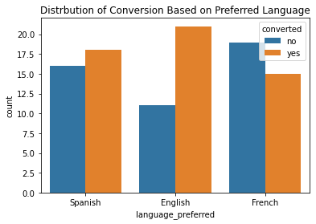

```python
sns.countplot(x='language_preferred',hue='converted',data=test);
plt.title("Distrbution of Conversion Based on Preferred Language")
plt.show()
```

```python
#Separating the data by preferred language
spanish = test[test['language_preferred']=='Spanish'].dropna()
english = test[test['language_preferred']=='English'].dropna()
french = test[test['language_preferred']=='French'].dropna()

pd.crosstab(test['converted'],test['language_preferred'])
```

| language_preferred converted | English | French | Spanish |
| --- | --- | --- | --- |
| no | 11 | 19 | 16 |
| yes | 21 | 15 | 18 |

It seems that most persons who select English will convert.

```python
#Calculation the conversion rates for each language
conv_span=(spanish['converted']=='yes').sum()/len(spanish)
conv_eng=(english['converted']=='yes').sum()/len(english)
conv_frn=(french['converted']=='yes').sum()/len(french)

if(conv_span>conv_eng):
    if(conv_span>conv_frn):
        print('Those whose preferred language is Spanish have the highest conversion rate. The conversion rate for Spanish is: ', round(conv_span,5))
    if(conv_span<conv_frn):
        print('Those whose preferred language is French have the highest conversion rate. The conversion rate for French is: ', round(conv_frn,5))
else:
    print('Those whose preferred language is English have the highest conversion rate. The conversion rate for English is: ', round(conv_eng,5))
```

```
Those whose preferred language is English have the highest conversion rate. The conversion rate for English is:  0.65625
```

### Using the Chi-Squared Test of Independense

We will test the null hypothesis

> $H_0:$ Conversion rate and Preferred Language are independent of each other

against the alternate hypothesis

> $H_a:$ The conversion rate depends on the preferred language of the landing page

### Assumptions:

- Categorical variables - Yes
- Expected value of the number of sample observations in each level of the variable is at least 5 - Yes, the number of observations in each level is greater than 5.
- Random sampling from the population - Yes, we are informed that the collected sample is a simple random sample.

### Let's find the p-value

```python
# import the required function
from scipy.stats import chi2_contingency

#creating a data frame with the data


# find the p-value
chi, p_val, dof, expected = chi2_contingency(pd.crosstab(test['converted'],test['language_preferred']))
print('The p-value is', p_val)
```

```
The p-value is 0.21298887487543447
```

Since the p value of the test is 21.3% which is much greater than the level of significance of 5%, we fail to reject the null hypothesis and therefore it that the conversion rate is not dependent on the preferred language chosen.

## Is the mean time spent on the new page same for the different language users?

```python
#Creating new data frames seprating users of the new page by preferred language
new_span = test_new[test_new['language_preferred']=='Spanish']
new_eng = test_new[test_new['language_preferred']=='English']
new_frn = test_new[test_new['language_preferred']=='French']

#Calculating the mean time spent in each preferred language
test_new.groupby(by='language_preferred')['time_spent_on_the_page'].mean()
```

```
language_preferred
English    6.663750
French     6.196471
Spanish    5.835294
Name: time_spent_on_the_page, dtype: float64
```

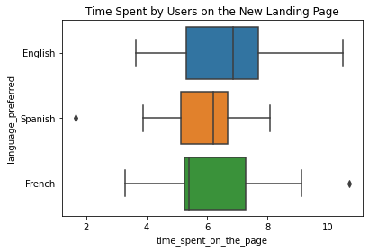

```python
#Visually displaying the distrubtion of time spent on the page by users of different languages
sns.boxplot(y='language_preferred',x='time_spent_on_the_page',data=test_new);
plt.title('Time Spent by Users on the New Landing Page')
plt.show()
```

#### Testing the statistical significance of this statement

### Anova Test

Let $\mu_s, \mu_e, \mu_f$ be the means of time spent for language preference spanish, english and french respectively.

We will test the null hypothesis

> $H_0: \mu_s = \mu_e = \mu_f$

against the alternative hypothesis

> $H_a: $ At least one language preference spends more time on average than the others.

Testing for normality and equality of variance assumptions.

- For testing of normality, Shapiro-Wilk’s test is applied to the response variable.
- For equality of variance, Levene test is applied to the response variable.

##### Shapiro-Wilk’s test

We will test the null hypothesis

> $H_0:$ Time spent on the page follows a normal distribution

against the alternative hypothesis

> $H_a:$ Time spent on the page does not follow a normal distribution

```python
# Assumption 1: Normality
# import the required function
from scipy import stats

# find the p-value
w, p_value = stats.shapiro(test_new['time_spent_on_the_page'])
print('The p-value is', p_value)
```

```
The p-value is 0.8040016293525696
```

Since the p value of the test is 80.4% which is much greater than the level of significance of 5%, we faily to reject the null hypothesis and therefore the time spent on the page seems to follow a normal distribution.

##### Levene’s test

We will test the null hypothesis

> $H_0$: All the population variances are equal

against the alternative hypothesis

> $H_a$: At least one variance is different from the rest

```python
#Assumption 2: Homogeneity of Variance
#import the required function
from scipy.stats import levene
statistic, p_value = levene(new_span['time_spent_on_the_page'],new_eng['time_spent_on_the_page'], new_frn['time_spent_on_the_page'])
# find the p-value
print('The p-value is', p_value)
```

```
The p-value is 0.46711357711340173
```

Since the p value, 46.7%, is large relative to the level of significant, 5%, we fail to reject the null and thus all of the population variances are equal.

Assumptions:

- The populations are normally distributed - Yes, verified by the Shapiro-Wilk's test
- Samples are independent simple random samples - Yes this was stated in the description
- Population variances are equal - Yes, verified by Levene's test

#### Calculating the p value for the tests of equality of the mean time

```python
#import the required function
from scipy.stats import f_oneway

# perform one-way anova test
test_stat, p_value = f_oneway(new_span['time_spent_on_the_page'],new_eng['time_spent_on_the_page'], new_frn['time_spent_on_the_page'])
print('The p-value is ' + str(p_value))
```

```
The p-value is 0.43204138694325955
```

The p value, 43.2% is much larger than the level of significance of 5%, therefore we faily to reject the null hypothesis. That is the data suggest that for users given the new page, the time spent on the page does not seem to be determined by the preferred language, i.e. they are the same.